# CaRT Demonstration

JAS

## Demonstration of Classification and Regression Trees (CaRT) using R

This demonstration of classification and regression trees (CaRT) will utilize the 2019 County Health Rankings. The rankings provide data on a number of demographic, social and environmental health characteristics for counties in the United States. We will be using this dataset to address two research questions.

1. What are the predictors of life expectancy on a county-level?
2. Imagine a scenario where the maintainers of the CHR were concerned that the data on firearm fatalities would no longer be made public. This information has been use by a number of foundations to target population-based interventions at reducing gun violence. They are wondering if the counties with higher proportions of firearm fatalities would still be able to be identified, based on the other data within the CHR. That is, can the other data in the CHR be used to classify counties according to having higher or lower firearm_fatalities?

The first question will be addressed with a regression tree, while the second will be addressed with a classification tree.

### Load needed packages

We will be using two different packages: rpart and caret. Both of these packages allow us to construct classification and regression trees, but they have different levels of functionality. Also loading rpart.plot which makes cleaner looking plots of the trees.

```r
library(tidyverse)
library(rpart)
library(caret)
```

```r
library(rpart.plot)
library(pROC)
library(kernlab)
```

### Load and check data

Variable names in the original dataset were not informative, so we need to append our own as column names. We also need to strip off the Id variable for easier processing. We’re also going to look at some basic descriptives of the data to determine if it needs cleaning, imputation of missing data, etc.

```r
chr<-read.csv("chr.csv")

#Stripping off ID Variable
chr<-chr[,2:68]

#Assigning informative variable names
var.names<-c("pre_death", "poorhealth", "poorphyshealth_days", "poormenthealth_days", "low_bwt", "ad_smoking", "ad_obesity", "foodenv_index", "phys_inactivity", "exer_access", "excess_drink", "alc_drivdeaths", "sti", "teen_birth", "uninsured", "primcareproviders", "dentists", "menthealthproviders", "prevhosp", "mammo_screen", "flu_vacc", "hsgrad", "somecollege", "unemployed", "child_poverty", "income_ineq", "sing_parent", "social_assoc", "violent_crime", "injury_deaths", "pm_air", "water_viol", "housing_prob", "driving_alone", "long_commute", "life_exp", "age_adj_premortality", "freq_physdistress", "freq_mentdistress", "diabetes", "hiv", "food_insecure", "ltd_access_healthyfood", "mvcrash_deaths", "insuff_sleep", "uninsured_adults", "uninsured_child", "other_pcp", "medhhinc", "freelunch_child", "res_seg_bw", "res_seg_nw", "firearm_fatalities", "homeownership", "hous_cost_burden", "population", "bw18", "gte65", "nonhisp_afam", "AmerInd_AlasNative", "Asian", "OPacIslander", "Hisp", "nonhisp_white", "nonprof_english", "female", "rural")
colnames(chr)<-var.names

#Stripping off premature mortality and premature death as they are different metrics of mortality that will improve prediction of
chr$age_adj_premortality<-NULL
chr$pre_death<-NULL

#Will identify any rows that do not have complete cases (i.e. have missing data); these data have no missing values
miss.rows<-chr[!complete.cases(chr),]

summary(chr)
```

```
##    poorhealth      poorphyshealth_days poormenthealth_days    low_bwt
##  Min.   :0.08289   Min.   :2.324       Min.   :2.440       Min.   :0.02646
##  1st Qu.:0.13948   1st Qu.:3.393       1st Qu.:3.493       1st Qu.:0.06794
##  Median :0.16687   Median :3.869       Median :3.932       Median :0.07877
##  Mean   :0.17468   Mean   :3.920       Mean   :3.932       Mean   :0.08112
##  3rd Qu.:0.20432   3rd Qu.:4.409       3rd Qu.:4.348       3rd Qu.:0.09029
##  Max.   :0.40732   Max.   :7.231       Max.   :5.964       Max.   :0.26136
##    ad_smoking        ad_obesity     foodenv_index    phys_inactivity
##  Min.   :0.06735   Min.   :0.1360   Min.   : 0.000   Min.   :0.0840
##  1st Qu.:0.15234   1st Qu.:0.2930   1st Qu.: 6.900   1st Qu.:0.2220
##  Median :0.17316   Median :0.3230   Median : 7.700   Median :0.2560
##  Mean   :0.17867   Mean   :0.3203   Mean   : 7.465   Mean   :0.2564
##  3rd Qu.:0.20275   3rd Qu.:0.3500   3rd Qu.: 8.200   3rd Qu.:0.2910
##  Max.   :0.42754   Max.   :0.4950   Max.   :10.000   Max.   :0.4510
##   exer_access      excess_drink     alc_drivdeaths        sti
##  Min.   :0.0000   Min.   :0.09265   Min.   :0.0000   Min.   :  40.1
##  1st Qu.:0.4928   1st Qu.:0.15102   1st Qu.:0.2033   1st Qu.: 224.0
##  Median :0.6671   Median :0.17403   Median :0.2857   Median : 336.8
##  Mean   :0.6319   Mean   :0.17431   Mean   :0.2927   Mean   : 385.2
##  3rd Qu.:0.8028   3rd Qu.:0.19678   3rd Qu.:0.3600   3rd Qu.: 469.2
##  Max.   :1.0000   Max.   :0.29440   Max.   :1.0000   Max.   :3543.9
##    teen_birth        uninsured       primcareproviders      dentists
##  Min.   :  2.395   Min.   :0.02068   Min.   :0.0000000   Min.   :0.0000000
##  1st Qu.: 21.339   1st Qu.:0.07156   1st Qu.:0.0003311   1st Qu.:0.0002661
##  Median : 31.432   Median :0.10364   Median :0.0005104   Median :0.0004211
##  Mean   : 31.983   Mean   :0.11108   Mean   :0.0005494   Mean   :0.0004571
##  3rd Qu.: 40.934   3rd Qu.:0.13987   3rd Qu.:0.0007067   3rd Qu.:0.0006041
##  Max.   :110.236   Max.   :0.33454   Max.   :0.0047722   Max.   :0.0072513
##  menthealthproviders    prevhosp      mammo_screen       flu_vacc
##  Min.   :0.0000000   Min.   :  471   Min.   :0.0700   Min.   :0.0300
##  1st Qu.:0.0004945   1st Qu.: 3680   1st Qu.:0.3500   1st Qu.:0.3500
##  Median :0.0011861   Median : 4668   Median :0.4000   Median :0.4200
##  Mean   :0.0015167   Mean   : 4820   Mean   :0.3999   Mean   :0.4055
##  3rd Qu.:0.0019290   3rd Qu.: 5721   3rd Qu.:0.4500   3rd Qu.:0.4800
##  Max.   :0.0200266   Max.   :33333   Max.   :0.6200   Max.   :0.6500
##      hsgrad        somecollege       unemployed      child_poverty
##  Min.   :0.2564   Min.   :0.1676   Min.   :0.01624   Min.   :0.0270
##  1st Qu.:0.8471   1st Qu.:0.4953   1st Qu.:0.03522   1st Qu.:0.1470
##  Median :0.8918   Median :0.5791   Median :0.04362   Median :0.2040
##  Mean   :0.8825   Mean   :0.5774   Mean   :0.04612   Mean   :0.2149
```

[output cut: 64 more lines]

```
##  Max.   :0.853296   Max.   :0.926969   Max.   :0.430067   Max.   :0.4772727
##       Hisp          nonhisp_white    nonprof_english        female
##  Min.   :0.005151   Min.   :0.0276   Min.   :0.000000   Min.   :0.2657
##  1st Qu.:0.023124   1st Qu.:0.6428   1st Qu.:0.002801   1st Qu.:0.4942
##  Median :0.043213   Median :0.8346   Median :0.007502   Median :0.5032
##  Mean   :0.095168   Mean   :0.7616   Mean   :0.017475   Mean   :0.4990
##  3rd Qu.:0.098455   3rd Qu.:0.9247   3rd Qu.:0.018927   3rd Qu.:0.5103
##  Max.   :0.963230   Max.   :0.9792   Max.   :0.353053   Max.   :0.5700
##      rural
##  Min.   :0.0000
##  1st Qu.:0.3260
##  Median :0.5876
##  Mean   :0.5806
##  3rd Qu.:0.8590
##  Max.   :1.0000
```

```r
#variables have very different distributions, but tree-based methods do not require scaling.

#Create the variable for Part 2, an indicator of having fire-arm fatalities above the median

chr$firearm.class<-as.factor(ifelse(chr$firearm_fatalities>median(chr$firearm_fatalities),1,0))
summary(chr$firearm.class)
```

```
##    0    1
## 2210  983
```

```r
#Note that data are slightly unbalanced.
```

### Partition data into training and testing sets.

```r
set.seed(123)
#To address Question 1
training.data.q1<-chr$life_exp %>% createDataPartition(p=0.7, list=F)
train.data.q1<-chr[training.data.q1, ]
test.data.q1<-chr[-training.data.q1, ]

#Remove firearm.class variable as its only used for Question 2
train.data.q1$firearm.class<-NULL
test.data.q1$firearm.class<-NULL

#To address Question 2
training.data.q2<-chr$firearm.class%>% createDataPartition(p=0.7, list=F)
train.data.q2<-chr[training.data.q2, ]
test.data.q2<-chr[-training.data.q2, ]

#Remove firearm fatalities variable as it was used to create our new outcome variable
train.data.q2$firearm_fatalities<-NULL
test.data.q2$firearm_fatalities<-NULL
```

### PART 1: REGRESSION TREES

We will create a number of regression trees to predict life expectancy. Caret calls to rpart, but doesn’t have the same level of hyperparameter turning as rpart. In caret, you can only change cp the complexity parameter. In addition, caret automatically performs pruning (whereas in rpart you, by default, can see the full tree.)

From within caret, you can still visualize the tree and get measures of variable importance.

Variable Importance: “An overall measure of variable importance is the sum of the goodness of split measures for each split for which it was the primary variable.”

```r
modelLookup("rpart")
```

```
##   model parameter                label forReg forClass probModel
## 1 rpart        cp Complexity Parameter   TRUE     TRUE      TRUE
```

```r
set.seed(123)

#Using 10-fold cross-validation to train model
train.control<-trainControl(method="cv", number=10)

#Using rpart method to generate regression tree, using all variables in dataset to predict life expectancy
tree.lifexp.1<-train(life_exp~ . , data=train.data.q1, method="rpart",trControl=train.control)
tree.lifexp.1$bestTune
```

```
##           cp
## 1 0.07121066
```

```r
tree.lifexp.1$results
```

```
##           cp     RMSE  Rsquared      MAE    RMSESD RsquaredSD     MAESD
## 1 0.07121066 2.331187 0.3919349 1.713118 0.2925983 0.07196497 0.1343429
## 2 0.07317617 2.356872 0.3800458 1.732158 0.3023548 0.06336335 0.1323991
## 3 0.33400015 2.730567 0.3089629 2.055688 0.3725591 0.03899337 0.2553687
```

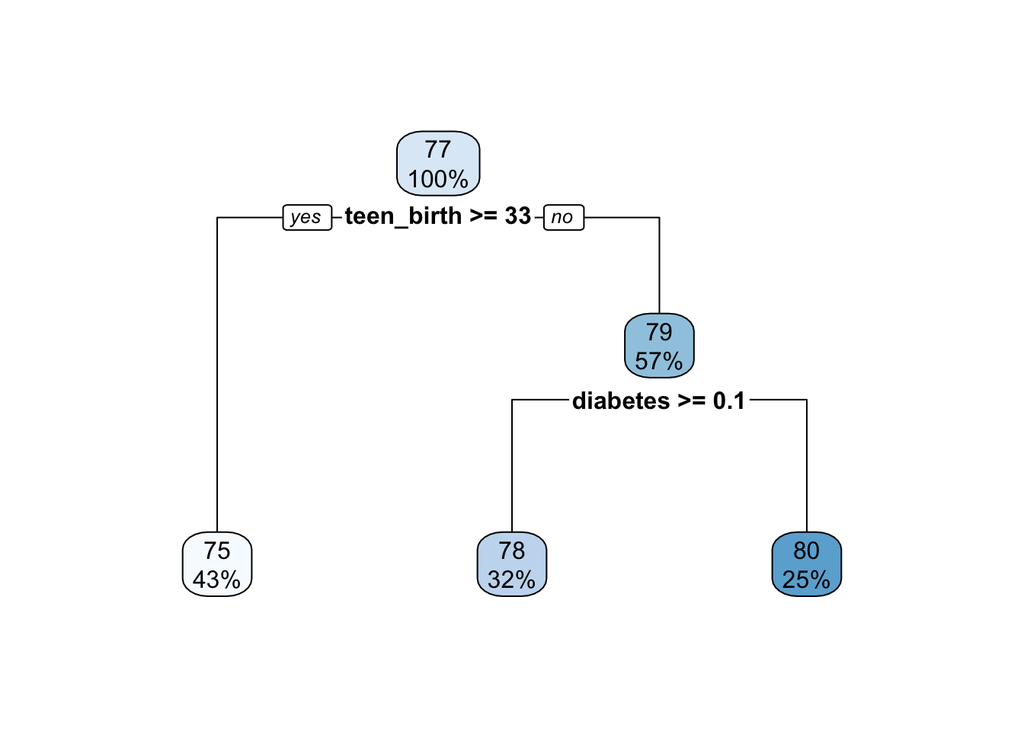

```r
#Can use rpart.plot function to visualize tree
rpart.plot(tree.lifexp.1$finalModel)
```

```r
#Applying model in testset to generate predictions and construct evaluation metrics

#First create predictions
pred.intest.temp<-predict(tree.lifexp.1, newdata=test.data.q1)
#Then use postResample to obtain evaluation metrics
postResample(pred.intest.temp, test.data.q1$life_exp)
```

```
##      RMSE  Rsquared       MAE
## 2.2300584 0.3979212 1.6579348
```

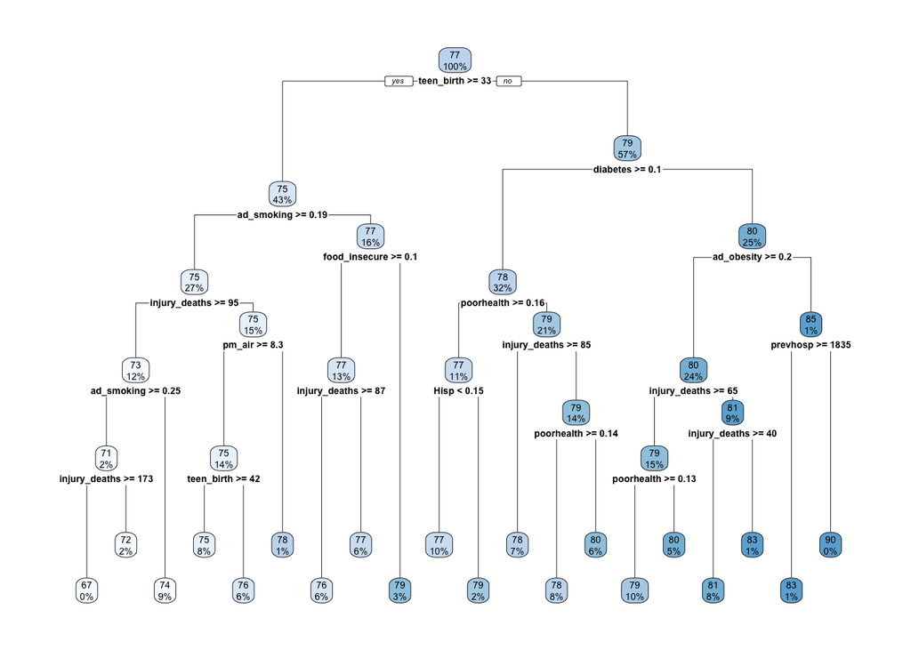

```r
#Specify tuneGrid so caret explores wider variety of cp-values
set.seed(123)
#Create different values of cp to try
cp.grid<-expand.grid(cp=seq(0.001,0.1, by=0.001))
tree.lifexp.2<-train(life_exp ~ ., data=train.data.q1, method="rpart", trControl=train.control, tuneGrid=cp.grid)

#Plot new "best" tree
rpart.plot(tree.lifexp.2$finalModel)
```

```r
tree.lifexp.2$bestTune
```

```
##      cp
## 6 0.006
```

```r
pred.intest.2<-predict(tree.lifexp.2, newdata=test.data.q1)
#Then use postResample to obtain evaluation metrics
postResample(pred.intest.2, test.data.q1$life_exp)
```

```
##      RMSE  Rsquared       MAE
## 1.8564915 0.5897789 1.3280170
```

```r
#Example variable importance in final model
varImp(tree.lifexp.2)
```

```
## rpart variable importance
##
##   only 20 most important variables shown (out of 64)
##
##                     Overall
## ad_smoking           100.00
## injury_deaths         90.15
## teen_birth            76.86
## freq_mentdistress     74.66
## poorhealth            68.38
## diabetes              61.09
## freq_physdistress     49.78
## food_insecure         46.35
## child_poverty         38.06
## phys_inactivity       33.16
## prevhosp              27.70
## pm_air                25.46
## nonprof_english       24.95
## AmerInd_AlasNative    21.41
## Hisp                  20.34
## poormenthealth_days   18.70
## ad_obesity            17.54
## medhhinc              15.62
## low_bwt               15.36
## income_ineq           14.55
```

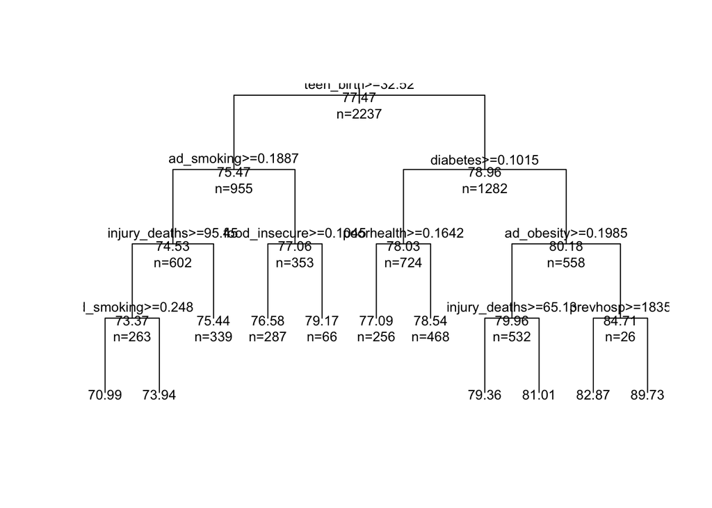

```r
#Sample code using rpart without caret, unpruned tree
tree.lifexp.3<-rpart(life_exp ~ ., data=train.data.q1, method="anova")
plot(tree.lifexp.3, uniform=TRUE)
text(tree.lifexp.3, use.n=TRUE, all=TRUE, cex=0.8)
```

```r
printcp(tree.lifexp.3)
```

```
##
## Regression tree:
## rpart(formula = life_exp ~ ., data = train.data.q1, method = "anova")
##
## Variables actually used in tree construction:
## [1] ad_obesity    ad_smoking    diabetes      food_insecure injury_deaths
## [6] poorhealth    prevhosp      teen_birth
##
## Root node error: 20023/2237 = 8.951
##
## n= 2237
##
##          CP nsplit rel error  xerror     xstd
## 1  0.334000      0   1.00000 1.00066 0.047669
## 2  0.073176      1   0.66600 0.68478 0.038237
## 3  0.071211      2   0.59282 0.60504 0.035158
## 4  0.031620      3   0.52161 0.55773 0.033553
## 5  0.027974      4   0.48999 0.54842 0.033301
## 6  0.017993      5   0.46202 0.51540 0.030763
## 7  0.017934      6   0.44403 0.51042 0.030621
## 8  0.017431      7   0.42609 0.50385 0.030507
## 9  0.016887      8   0.40866 0.49591 0.030299
## 10 0.012022      9   0.39177 0.47660 0.029824
## 11 0.010000     10   0.37975 0.46264 0.028990
```

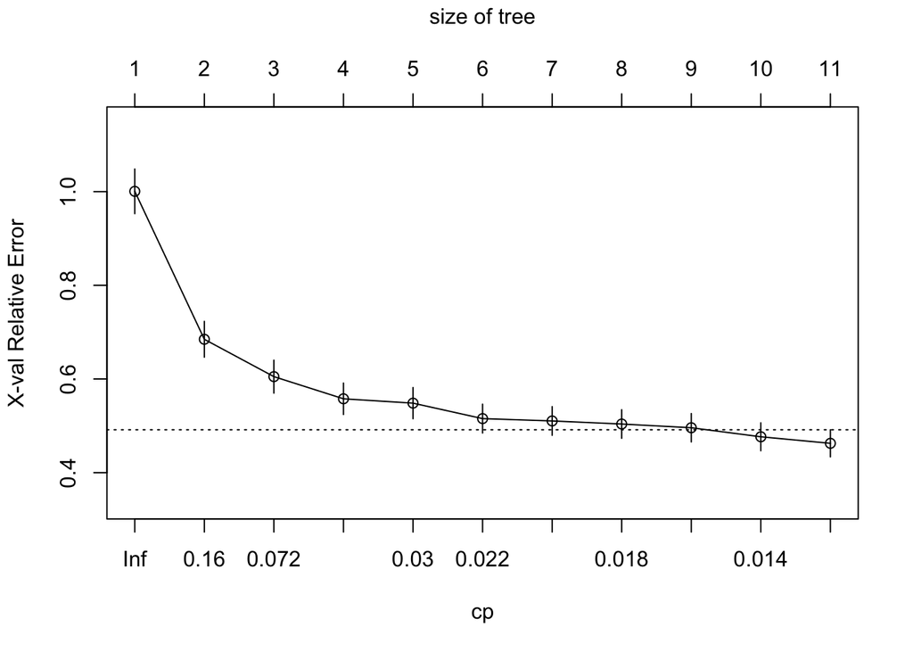

```r
plotcp(tree.lifexp.3)
```

```r
print(tree.lifexp.3)
```

```
## n= 2237
##
## node), split, n, deviance, yval
##       * denotes terminal node
##
##  1) root 2237 20023.44000 77.47202
##    2) teen_birth>=32.51939 955  5966.32300 75.46869
##      4) ad_smoking>=0.1887231 602  2817.88900 74.53301
##        8) injury_deaths>=95.449 263  1210.61200 73.36868
##         16) ad_smoking>=0.2480356 51   319.78930 70.98630 *
##         17) ad_smoking< 0.2480356 212   531.72340 73.94180 *
##        9) injury_deaths< 95.449 339   974.13340 75.43631 *
##      5) ad_smoking< 0.1887231 353  1722.55200 77.06439
##       10) food_insecure>=0.1045 287   951.70970 76.57993 *
##       11) food_insecure< 0.1045 66   410.56410 79.17108 *
##    3) teen_birth< 32.51939 1282  7369.28200 78.96436
##      6) diabetes>=0.1015 724  2636.26400 78.02581
##       12) poorhealth>=0.1641845 256   827.64600 77.08703 *
##       13) poorhealth< 0.1641845 468  1459.59200 78.53933 *
##      7) diabetes< 0.1015 558  3267.78000 80.18212
##       14) ad_obesity>=0.1985 532  2219.02700 79.96063
##         28) injury_deaths>=65.12574 338  1168.92800 79.35664 *
##         29) injury_deaths< 65.12574 194   711.97060 81.01293 *
##       15) ad_obesity< 0.1985 26   488.60940 84.71424
##         30) prevhosp>=1835 19    45.66227 82.86731 *
##         31) prevhosp< 1835 7   202.21790 89.72733 *
```

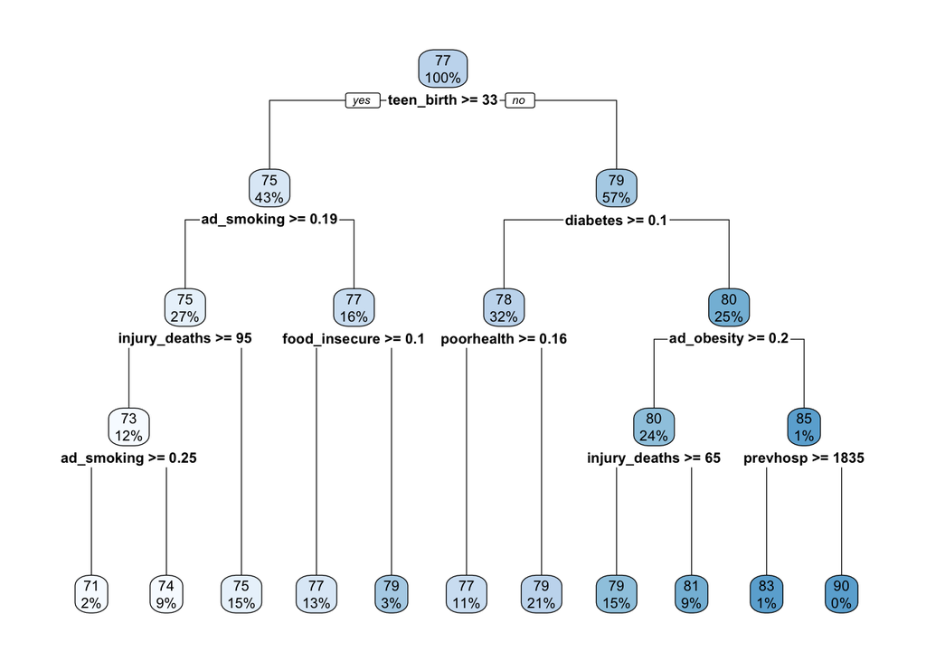

```r
rpart.plot(tree.lifexp.3)
```

```r
pred.intest.3 <- predict(tree.lifexp.3, newdata = test.data.q1)

postResample(pred.intest.3, test.data.q1$life_exp)
```

```
##      RMSE  Rsquared       MAE
## 1.9396359 0.5476211 1.4111937
```

```r
varImp(tree.lifexp.3)
```

```
##                          Overall
## ad_obesity             0.1714139
## ad_smoking             1.4992830
## AmerInd_AlasNative     0.3807150
## Asian                  0.1030206
## bw18                   0.2245019
## child_poverty          0.5839349
## diabetes               0.8615594
## firearm_fatalities     0.1297895
## food_insecure          0.3363820
## freq_mentdistress      0.6632015
## freq_physdistress      0.4336459
## Hisp                   0.2043574
## hsgrad                 0.2197707
## injury_deaths          0.5242530
## medhhinc               0.2777443
## nonprof_english        0.1677790
## phys_inactivity        0.4495001
## poorhealth             0.8338577
## poormenthealth_days    0.1965529
## prevhosp               0.4926824
## teen_birth             0.7582948
## uninsured              0.2503747
## uninsured_adults       0.2514430
## poorphyshealth_days    0.0000000
## low_bwt                0.0000000
## foodenv_index          0.0000000
## exer_access            0.0000000
## excess_drink           0.0000000
## alc_drivdeaths         0.0000000
## sti                    0.0000000
## primcareproviders      0.0000000
## dentists               0.0000000
## menthealthproviders    0.0000000
## mammo_screen           0.0000000
## flu_vacc               0.0000000
## somecollege            0.0000000
## unemployed             0.0000000
## income_ineq            0.0000000
## sing_parent            0.0000000
```

[output cut: 10 more lines]

```
## insuff_sleep           0.0000000
## uninsured_child        0.0000000
## other_pcp              0.0000000
## freelunch_child        0.0000000
## res_seg_bw             0.0000000
## res_seg_nw             0.0000000
## homeownership          0.0000000
## hous_cost_burden       0.0000000
## population             0.0000000
## gte65                  0.0000000
## nonhisp_afam           0.0000000
## OPacIslander           0.0000000
## nonhisp_white          0.0000000
## female                 0.0000000
## rural                  0.0000000
```

### PART 2 CLASSIFICATION TREES

```r
set.seed(123)

#Creating 10-fold cross-validation and using down-sampling because of imbalance in data
train.control.class<-trainControl(method="cv", number=10, sampling="down")

#Create sequence of cp parameters to try
grid.2<-expand.grid(cp=seq(0.001, 0.3, by=0.01))

#Train model
tree.firearm<-train(firearm.class~., data=train.data.q2, method="rpart",trControl=train.control.class, tuneGrid=grid.2)
tree.firearm$bestTune
```

```
##      cp
## 2 0.011
```

```r
tree.firearm
```

```
## CART
##
## 2236 samples
##   64 predictor
##    2 classes: '0', '1'
##
## No pre-processing
## Resampling: Cross-Validated (10 fold)
## Summary of sample sizes: 2012, 2012, 2012, 2013, 2012, 2013, ...
## Addtional sampling using down-sampling
##
## Resampling results across tuning parameters:
##
##   cp     Accuracy   Kappa
##   0.001  0.7347843  0.4318731
##   0.011  0.7661106  0.5157751
##   0.021  0.7531381  0.4940759
##   0.031  0.7486497  0.4766109
##   0.041  0.7607253  0.4706990
##   0.051  0.7442075  0.4448374
##   0.061  0.7236175  0.4123681
##   0.071  0.7195997  0.4054893
##   0.081  0.7195997  0.4054893
##   0.091  0.7195997  0.4054893
##   0.101  0.7195997  0.4054893
##   0.111  0.7195997  0.4054893
##   0.121  0.7195997  0.4054893
##   0.131  0.7195997  0.4054893
##   0.141  0.7195997  0.4054893
##   0.151  0.7195997  0.4054893
##   0.161  0.7195997  0.4054893
##   0.171  0.7195997  0.4054893
##   0.181  0.7195997  0.4054893
##   0.191  0.7195997  0.4054893
##   0.201  0.7195997  0.4054893
##   0.211  0.7195997  0.4054893
##   0.221  0.7195997  0.4054893
##   0.231  0.7195997  0.4054893
##   0.241  0.7195997  0.4054893
##   0.251  0.7195997  0.4054893
##   0.261  0.7195997  0.4054893
##   0.271  0.7195997  0.4054893
##   0.281  0.7195997  0.4054893
##   0.291  0.7195997  0.4054893
##
## Accuracy was used to select the optimal model using the largest value.
## The final value used for the model was cp = 0.011.
```

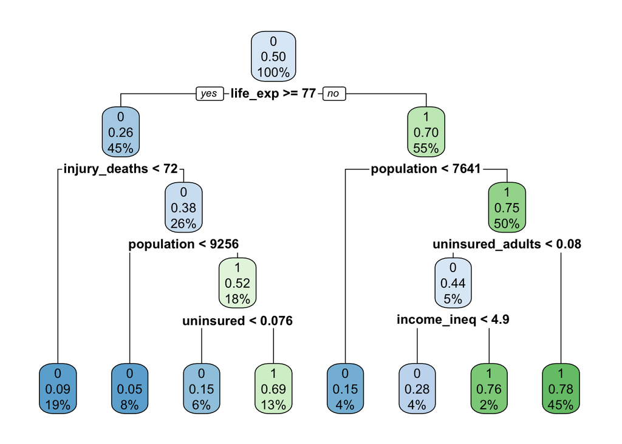

```r
rpart.plot(tree.firearm$finalModel)
```

```r
#Note you can obtain variable importance on the final model within training data
varImp(tree.firearm)
```

```
## rpart variable importance
##
##   only 20 most important variables shown (out of 64)
##
##                     Overall
## poorphyshealth_days 100.000
## life_exp             95.024
## food_insecure        84.529
## freq_mentdistress    73.771
## teen_birth           70.553
## population           49.572
## uninsured            44.874
## uninsured_adults     42.812
## injury_deaths        39.920
## freq_physdistress    26.429
## child_poverty        17.983
## uninsured_child      14.561
## low_bwt              13.788
## AmerInd_AlasNative   13.514
## poormenthealth_days  12.424
## social_assoc         11.422
## phys_inactivity      10.305
## pm_air                7.408
## income_ineq           5.267
## excess_drink          4.071
```

```r
#Note you can get accuracy metric and confusion matrix from training.
confusionMatrix(tree.firearm)
```

```
## Cross-Validated (10 fold) Confusion Matrix
##
## (entries are percentual average cell counts across resamples)
##
##           Reference
## Prediction    0    1
##          0 50.2  4.4
##          1 19.0 26.4
##
##  Accuracy (average) : 0.7661
```

```r
#Create predictions in test set
pred.firearm<-predict(tree.firearm, test.data.q2)

#Create predictions as probabilities on test set
pred.firearm.prob<-predict(tree.firearm, test.data.q2, type="prob")

eval.results<-confusionMatrix(pred.firearm, test.data.q2$firearm.class, positive = "1")
print(eval.results)
```

```
## Confusion Matrix and Statistics
##
##           Reference
## Prediction   0   1
##          0 473  34
##          1 190 260
##
##                Accuracy : 0.7659
##                  95% CI : (0.7378, 0.7924)
##     No Information Rate : 0.6928
##     P-Value [Acc > NIR] : 3.026e-07
##
##                   Kappa : 0.5209
##
##  Mcnemar's Test P-Value : < 2.2e-16
##
##             Sensitivity : 0.8844
##             Specificity : 0.7134
##          Pos Pred Value : 0.5778
##          Neg Pred Value : 0.9329
##              Prevalence : 0.3072
##          Detection Rate : 0.2717
##    Detection Prevalence : 0.4702
##       Balanced Accuracy : 0.7989
##
##        'Positive' Class : 1
##
```

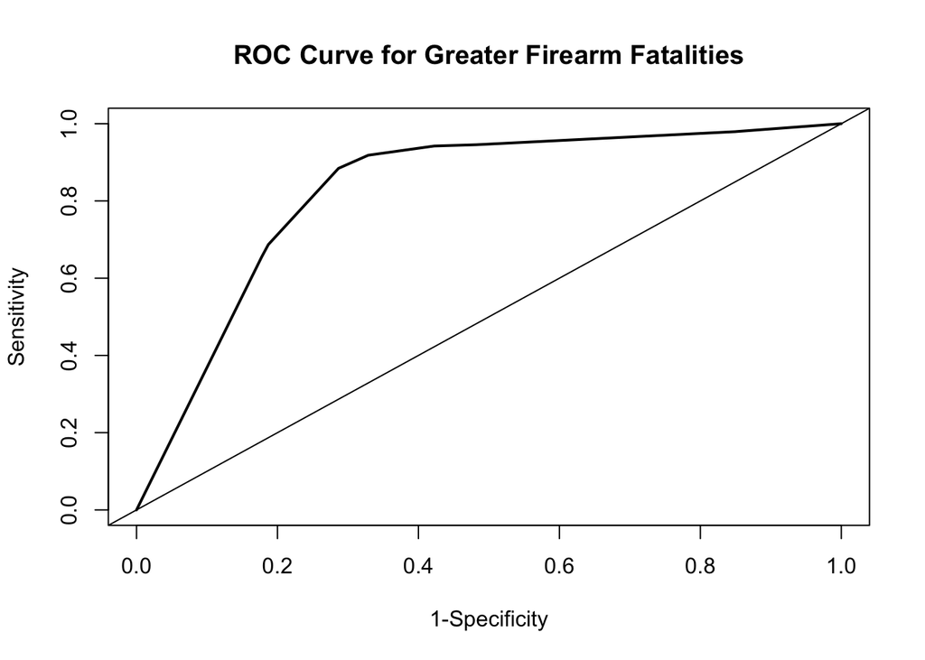

```r
#Another potential evaluation: Area under the Receiver Operating Curve (AUROC)
analysis <- roc(response=test.data.q2$firearm.class, predictor=pred.firearm.prob[,2])
plot(1-analysis$specificities,analysis$sensitivities,type="l",
ylab="Sensitivity",xlab="1-Specificity",col="black",lwd=2,
main = "ROC Curve for Greater Firearm Fatalities")
abline(a=0,b=1)
```

## Demonstration of Support Vector Classifiers

Data Citation: We are using a dataset containing features related to heart disease. There are 13 features and the outcome variable is a binary, classification variable indicating the presence of heart disease.

### Step 1: Load packages

e1071 contains the svm function. Again, we’ll be using caret

```r
library(e1071)
```

##Step 2: Load data and perform minor cleaning, check and recode missings etc. 1. How to load a flat text file 2. How to assign column names when none are provided 3. How to check variable types across the dataframe 4. How to recode missing indicators, change variable types and explore variable distributions

```r
heart.data <- read.csv("processed.cleveland.data", header=FALSE)

var.names<-c("age", "sex", "pain_type", "resting_sysbp", "chol", "fast_blsugar_gt120", "rest_ecg", "max_hr", "exerc_angina", "ST_depression", "ST_slope", "vessels_colorflu", "defect", "heart_disease_present")

colnames(heart.data)<-var.names
str(heart.data)
```

```
## 'data.frame':    303 obs. of  14 variables:
##  $ age                  : num  63 67 67 37 41 56 62 57 63 53 ...
##  $ sex                  : num  1 1 1 1 0 1 0 0 1 1 ...
##  $ pain_type            : num  1 4 4 3 2 2 4 4 4 4 ...
##  $ resting_sysbp        : num  145 160 120 130 130 120 140 120 130 140 ...
##  $ chol                 : num  233 286 229 250 204 236 268 354 254 203 ...
##  $ fast_blsugar_gt120   : num  1 0 0 0 0 0 0 0 0 1 ...
##  $ rest_ecg             : num  2 2 2 0 2 0 2 0 2 2 ...
##  $ max_hr               : num  150 108 129 187 172 178 160 163 147 155 ...
##  $ exerc_angina         : num  0 1 1 0 0 0 0 1 0 1 ...
##  $ ST_depression        : num  2.3 1.5 2.6 3.5 1.4 0.8 3.6 0.6 1.4 3.1 ...
##  $ ST_slope             : num  3 2 2 3 1 1 3 1 2 3 ...
##  $ vessels_colorflu     : chr  "0.0" "3.0" "2.0" "0.0" ...
##  $ defect               : chr  "6.0" "3.0" "7.0" "3.0" ...
##  $ heart_disease_present: int  0 2 1 0 0 0 3 0 2 1 ...
```

```r
heart.data[heart.data=="?"]<-NA

heart.data$defect<-as.numeric(factor(heart.data$defect))
heart.data$vessels_colorflu<-as.numeric(factor(heart.data$vessels_colorflu))

heart.data$outcome<-ifelse(heart.data$heart_disease_present==0, 0,1)
heart.data$heart_disease_present<-NULL
heart.data$outcome<-factor(heart.data$outcome)
levels(heart.data$outcome)<-c("HDNotPresent", "HDPresent")
str(heart.data)
```

```
## 'data.frame':    303 obs. of  14 variables:
##  $ age               : num  63 67 67 37 41 56 62 57 63 53 ...
##  $ sex               : num  1 1 1 1 0 1 0 0 1 1 ...
##  $ pain_type         : num  1 4 4 3 2 2 4 4 4 4 ...
##  $ resting_sysbp     : num  145 160 120 130 130 120 140 120 130 140 ...
##  $ chol              : num  233 286 229 250 204 236 268 354 254 203 ...
##  $ fast_blsugar_gt120: num  1 0 0 0 0 0 0 0 0 1 ...
##  $ rest_ecg          : num  2 2 2 0 2 0 2 0 2 2 ...
##  $ max_hr            : num  150 108 129 187 172 178 160 163 147 155 ...
##  $ exerc_angina      : num  0 1 1 0 0 0 0 1 0 1 ...
##  $ ST_depression     : num  2.3 1.5 2.6 3.5 1.4 0.8 3.6 0.6 1.4 3.1 ...
##  $ ST_slope          : num  3 2 2 3 1 1 3 1 2 3 ...
##  $ vessels_colorflu  : num  1 4 3 1 1 1 3 1 2 1 ...
##  $ defect            : num  2 1 3 1 1 1 1 1 3 3 ...
##  $ outcome           : Factor w/ 2 levels "HDNotPresent",..: 1 2 2 1 1 1 2 1 2 2 ...
```

```r
summary(heart.data)
```

```
##       age             sex           pain_type     resting_sysbp
##  Min.   :29.00   Min.   :0.0000   Min.   :1.000   Min.   : 94.0
##  1st Qu.:48.00   1st Qu.:0.0000   1st Qu.:3.000   1st Qu.:120.0
##  Median :56.00   Median :1.0000   Median :3.000   Median :130.0
##  Mean   :54.44   Mean   :0.6799   Mean   :3.158   Mean   :131.7
##  3rd Qu.:61.00   3rd Qu.:1.0000   3rd Qu.:4.000   3rd Qu.:140.0
##  Max.   :77.00   Max.   :1.0000   Max.   :4.000   Max.   :200.0
##
##       chol       fast_blsugar_gt120    rest_ecg          max_hr
##  Min.   :126.0   Min.   :0.0000     Min.   :0.0000   Min.   : 71.0
##  1st Qu.:211.0   1st Qu.:0.0000     1st Qu.:0.0000   1st Qu.:133.5
##  Median :241.0   Median :0.0000     Median :1.0000   Median :153.0
##  Mean   :246.7   Mean   :0.1485     Mean   :0.9901   Mean   :149.6
##  3rd Qu.:275.0   3rd Qu.:0.0000     3rd Qu.:2.0000   3rd Qu.:166.0
##  Max.   :564.0   Max.   :1.0000     Max.   :2.0000   Max.   :202.0
##
##   exerc_angina    ST_depression     ST_slope     vessels_colorflu
##  Min.   :0.0000   Min.   :0.00   Min.   :1.000   Min.   :1.000
##  1st Qu.:0.0000   1st Qu.:0.00   1st Qu.:1.000   1st Qu.:1.000
##  Median :0.0000   Median :0.80   Median :2.000   Median :1.000
##  Mean   :0.3267   Mean   :1.04   Mean   :1.601   Mean   :1.672
##  3rd Qu.:1.0000   3rd Qu.:1.60   3rd Qu.:2.000   3rd Qu.:2.000
##  Max.   :1.0000   Max.   :6.20   Max.   :3.000   Max.   :4.000
##                                                  NA's   :4
##      defect              outcome
##  Min.   :1.000   HDNotPresent:164
##  1st Qu.:1.000   HDPresent   :139
##  Median :1.000
##  Mean   :1.837
##  3rd Qu.:3.000
##  Max.   :3.000
##  NA's   :2
```

```r
#Remove the missings
heart.data.nomiss<-na.omit(heart.data)

#Set No Heart Disease as Reference Level
heart.data.nomiss$outcome<-relevel(heart.data.nomiss$outcome, ref="HDNotPresent")
```

### Step 3: Partition data into training and testing

```r
set.seed(123)

train.indices<-createDataPartition(y=heart.data.nomiss$outcome,p=0.7,list=FALSE)
training<-heart.data.nomiss[train.indices,]
testing<-heart.data.nomiss[-train.indices,]
```

### Train support vector classifier (or support vector machine with linear kernal) in Caret

```r
modelLookup("svmLinear")
```

```
##       model parameter label forReg forClass probModel
## 1 svmLinear         C  Cost   TRUE     TRUE      TRUE
```

```r
set.seed(123)

#Set 10-fold cross-validation. Note if you want predicted probabilities, you need to set class Probs=True
train_control<-trainControl(method="cv", number=10, classProbs = T)

#Train model. Note we are scaling data
svm.caret<-train(outcome ~ ., data=training, method="svmLinear", trControl=train_control, preProcess=c("center", "scale"))
svm.caret
```

```
## Support Vector Machines with Linear Kernel
##
## 208 samples
##  13 predictor
##   2 classes: 'HDNotPresent', 'HDPresent'
##
## Pre-processing: centered (13), scaled (13)
## Resampling: Cross-Validated (10 fold)
## Summary of sample sizes: 186, 188, 187, 187, 187, 188, ...
## Resampling results:
##
##   Accuracy   Kappa
##   0.8170996  0.6322884
##
## Tuning parameter 'C' was held constant at a value of 1
```

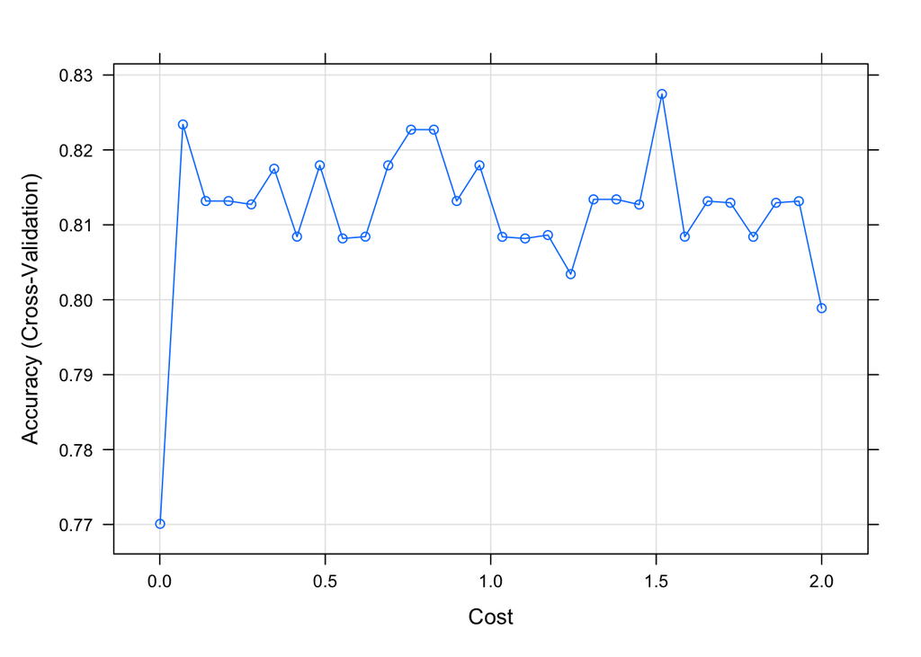

```r
#Incorporate different values for cost (C)
svm.caret.2<-train(outcome ~ ., data=training, method="svmLinear",  trControl=train_control, preProcess=c("center", "scale"), tuneGrid=expand.grid(C=seq(0.001,2, length=30)))

#Visualize accuracy versus values of C
plot(svm.caret.2)
```

```r
#Obtain metrics of accuracy from training
confusionMatrix(svm.caret.2)
```

```
## Cross-Validated (10 fold) Confusion Matrix
##
## (entries are percentual average cell counts across resamples)
##
##               Reference
## Prediction     HDNotPresent HDPresent
##   HDNotPresent         46.6      10.1
##   HDPresent             7.2      36.1
##
##  Accuracy (average) : 0.8269
```

```r
#See information about final model
svm.caret.2$finalModel
```

```
## Support Vector Machine object of class "ksvm"
##
## SV type: C-svc  (classification)
##  parameter : cost C = 1.51748275862069
##
## Linear (vanilla) kernel function.
##
## Number of Support Vectors : 82
##
## Objective Function Value : -112.9472
## Training error : 0.153846
## Probability model included.
```

```r
#Make predictions in testset
svm.pred.test<-predict(svm.caret.2, testing)

#Get evaluation metrics from test set
confusionMatrix(svm.pred.test, testing$outcome, positive="HDPresent")
```

```
## Confusion Matrix and Statistics
##
##               Reference
## Prediction     HDNotPresent HDPresent
##   HDNotPresent           44        10
##   HDPresent               4        31
##
##                Accuracy : 0.8427
##                  95% CI : (0.7502, 0.9112)
##     No Information Rate : 0.5393
##     P-Value [Acc > NIR] : 1.452e-09
##
##                   Kappa : 0.68
##
##  Mcnemar's Test P-Value : 0.1814
##
##             Sensitivity : 0.7561
##             Specificity : 0.9167
##          Pos Pred Value : 0.8857
##          Neg Pred Value : 0.8148
##              Prevalence : 0.4607
##          Detection Rate : 0.3483
##    Detection Prevalence : 0.3933
##       Balanced Accuracy : 0.8364
##
##        'Positive' Class : HDPresent
##
```

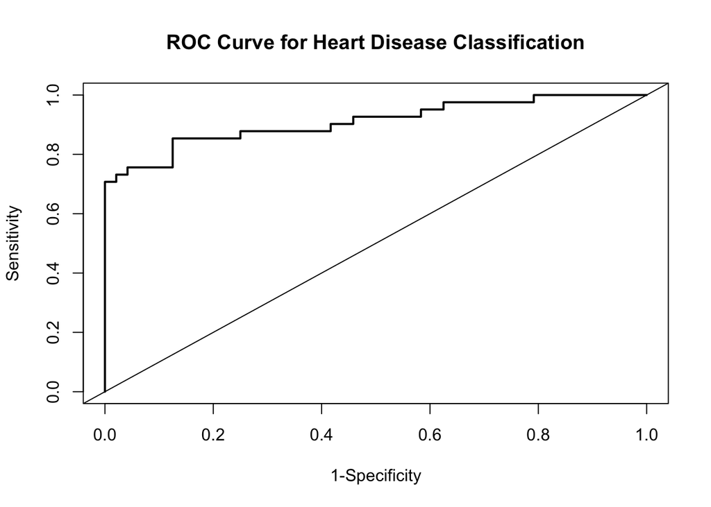

```r
#Create ROC Curve for Analysis
pred.prob<-predict(svm.caret.2, testing, type="prob")

#Another potential evaluation: Area under the Reciver Operating Curve (AUROC)
analysis <- roc(response=testing$outcome, predictor=pred.prob[,2])
plot(1-analysis$specificities,analysis$sensitivities,type="l",
ylab="Sensitivity",xlab="1-Specificity",col="black",lwd=2,
main = "ROC Curve for Heart Disease Classification")
abline(a=0,b=1)
```

### Notes about Variable Importance

Variable Importance for the SVC For SVM classification models, most packages do not have built-in variable importance. The default behavior in caret for SVM is to compute the area under the ROC curve. FROM DOCUMENTATION FOR CARET For classification, ROC curve analysis is conducted on each predictor. For two class problems, a series of cutoffs is applied to the predictor data to predict the class. The sensitivity and specificity are computed for each cutoff and the ROC curve is computed. The trapezoidal rule is used to compute the area under the ROC curve. This area is used as the measure of variable importance. More detail is

https://topepo.github.io/caret/variable-importance.html

```r
varImp(svm.caret.2)
```

```
## ROC curve variable importance
##
##                    Importance
## pain_type              100.00
## defect                  92.64
## vessels_colorflu        86.40
## ST_depression           86.25
## max_hr                  80.48
## exerc_angina            70.12
## ST_slope                66.98
## sex                     48.78
## age                     31.14
## resting_sysbp           29.07
## rest_ecg                28.23
## chol                    17.51
## fast_blsugar_gt120       0.00
```